# Spiny lobster abundance, community size structure, and fishing pressure along the Santa Barbara coast (2012 - 2018)

Co-authors: Julia Dagum and Kelsie Fronheiser

### Results

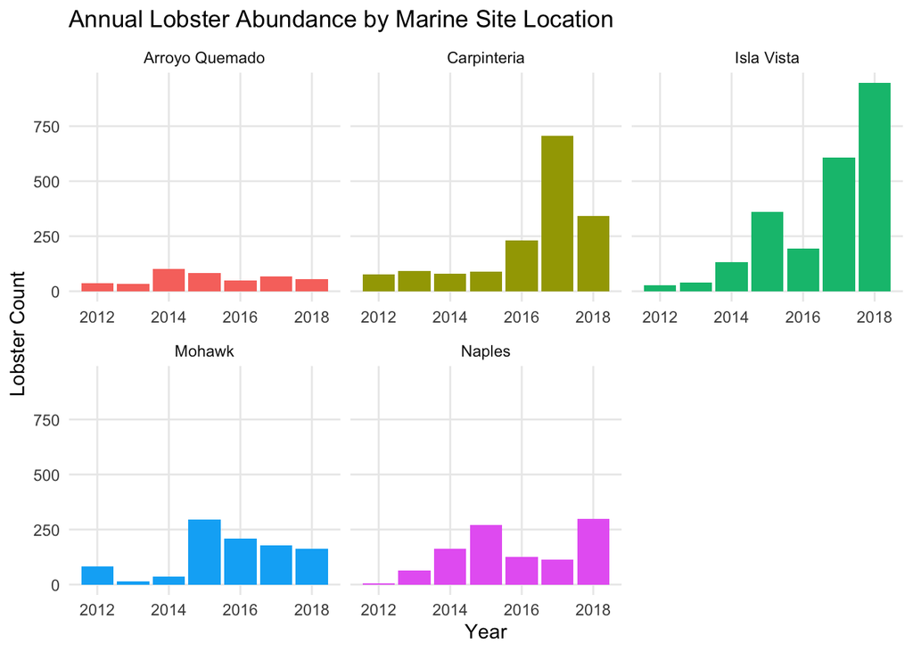

#### B. Lobster Sizes in 2012 and 2018

Overall, the lobster sizes are normally distributed and seem to be centered around a mean with little skew at most sites. However, there are some outliers in the data from Carpenteria and Isla Vista in 2012 that skew the mean positively.

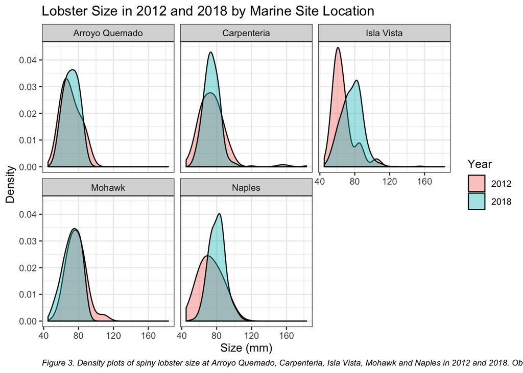

When observing lobster sizes at the various locations in 2012 and 2018, the trend that stands out the most is the difference in size distributions at the Isla Vista and Naples sites. These two sites are Marine Protected Areas (MPAs), and show a distinct shift towards greater sizes in 2018 compared to 2012. While the differences appear meaningful from the distribution graphs, it is also important to note the number of observations in each sample. In 2012, only 32 lobsters were observed at MPA sites (Isla Vista and Naples combined), while in 2018, 1244 lobsters were observed. While protecting these sites may have resulted in increased spiny lobster populations, it also may affect the distribution of sizes since the 2018 sample size is so much larger.

Another interesting trend seems to be that at every site, with the exception of Isla Vista, the spread of the data seems to have slightly decreased from 2012 - 2018 and there are more observations closer to the mean. While the Arroyo Quemado and Mohawk sites did not have a large difference in sample size between 2012 and 2018, the Naples, Isla Vista, and Carpenteria sites had a greater number observations in 2018 compared to 2012, based on the graphs from part A. These sample sizes may have resulted in the data becoming more centered around the mean.

Welch’s t-test was used in R (Version 3.6.1, released 2019-07-05) with a significance level of *p* < 0.005 to compare mean lobster sizes at MPA and non-MPA sites in 2012 and 2018. Percent change and effect size using Cohen’s *d* were also used to further analyze the data and enhance the evidence provided by the t-test.

#### C. Comparison of mean lobster size at MPA and non-MPA sites in 2012 and 2018

Mean lobster sizes in 2012 at MPA sites (67 ± 12 mm, n = 32) and non-MPA sites (75 ± 12 mm, n = 199) differed significantly (t(42.09) = -3.25, *p* < 0.005). This makes sense because it is likely one of the reasons the sites needed to be protected initially.

Mean lobster sizes in 2018 at MPA sites (78 ± 12 mm, n = 1244) and non-MPA sites (74 ± 10 mm, n = 561) also differed significantly (t(1239.51) = 7.31, *p* < 0.005), based on analysis using Welch’s t-test. However, because the sample sizes are so large for these observations, small effects could produce statistically significant results. The mean lobster sizes for the MPA and non-MPA sites only differed by about 4 mm, which is less than 1/2 of the standard deviation of the samples collected at either site. While the difference is statistically significant, the effect size is small to moderate (Cohen’s *d* = 0.36. This implies that while the MPA sites do not result in vastly greater lobster sizes compared to non-MPA sites, they have increased lobster size compared to their initial 2012 values, which could be considered a measure of success in protecting the area.

Upon observing non-MPA sites in 2012 (75 ± 12 mm, n = 199) and 2018 (74 ± 10 mm, n = 561), it is clear that there is no significant difference in mean lobster sizes (t(296.01) = 1.33, *p* = 0.18). The mean size decreased by only about 1%, from 75 mm to 74 mm. This serves to reinforce the evidence that the MPA sites have resulted in increased mean lobster size from 2012 - 2018, while the non-MPA sites have not had a significant effect.

Figure 4. Summary table of lobster size data at MPA and non-MPA sites in 2012 and 2018 including lobster size means, standard deviations and sample sizes.

| Type of Site | Year | Mean Size | Standard Deviation | Sample Size |
| --- | --- | --- | --- | --- |
| MPA | 2012 | 67.37500 | 12.15425 | 32 |
| MPA | 2018 | 77.56672 | 11.70341 | 1244 |
| non-MPA | 2012 | 74.92462 | 12.41412 | 199 |
| non-MPA | 2018 | 73.61996 | 10.09438 | 561 |